# Ridge, Lasso, and Elastic Net Practice

# Ridge, Lasso, and Elastic Net Practice

```r
library(glmnet)
library(MASS)
library(ISLR)
set.seed(123)
```

# How to use this notebook

This practice file is designed to help you build intuition for when ridge, lasso, and elastic net work best.

You will work through four scenarios:

1. A classic medium-sized real dataset with mixed predictors
2. A dataset with multicollinearity
3. A synthetic dataset where only a few predictors truly matter
4. A high-dimensional dataset where p > n

For each section: - fit ridge, lasso, and elastic net - compare cross-validated test error - inspect coefficients - answer reflection questions

# Helper functions

```r
rmse <- function(actual, predicted) {
  sqrt(mean((actual - predicted)^2))
}

fit_three_models <- function(x_train, y_train, x_test, y_test, alpha_enet = 0.5) {
  ridge_cv <- cv.glmnet(x_train, y_train, alpha = 0)
  lasso_cv <- cv.glmnet(x_train, y_train, alpha = 1)
  enet_cv  <- cv.glmnet(x_train, y_train, alpha = alpha_enet)

  pred_ridge <- predict(ridge_cv, newx = x_test, s = "lambda.min")
  pred_lasso <- predict(lasso_cv, newx = x_test, s = "lambda.min")
  pred_enet  <- predict(enet_cv,  newx = x_test, s = "lambda.min")

  out <- data.frame(
    model = c("ridge", "lasso", paste0("elastic_net_alpha_", alpha_enet)),
    lambda_min = c(ridge_cv$lambda.min, lasso_cv$lambda.min, enet_cv$lambda.min),
    test_rmse = c(
      rmse(y_test, pred_ridge),
      rmse(y_test, pred_lasso),
      rmse(y_test, pred_enet)
    )
  )

  list(
    summary = out,
    ridge = ridge_cv,
    lasso = lasso_cv,
    enet = enet_cv
  )
}

nonzero_count <- function(model) {
  sum(coef(model, s = "lambda.min")[-1, 1] != 0)
}
```

# 1) Hitters: a classic practice dataset

```r
data(Hitters)
hitters <- na.omit(Hitters)

x <- model.matrix(Salary ~ ., hitters)[, -1]
y <- hitters$Salary

set.seed(1)
train_id <- sample(seq_len(nrow(x)), size = floor(0.7 * nrow(x)))

x_train <- x[train_id, ]
x_test  <- x[-train_id, ]
y_train <- y[train_id]
y_test  <- y[-train_id]

hitters_fit <- fit_three_models(x_train, y_train, x_test, y_test)
hitters_fit$summary
```

```
##                   model lambda_min test_rmse
## 1                 ridge 26.0890800  369.3729
## 2                 lasso  0.4251870  365.3940
## 3 elastic_net_alpha_0.5  0.4866153  365.6901
```

## Coefficient counts

```r
data.frame(
  model = c("ridge", "lasso", "elastic_net"),
  nonzero = c(
    nonzero_count(hitters_fit$ridge),
    nonzero_count(hitters_fit$lasso),
    nonzero_count(hitters_fit$enet)
  )
)
```

```
##         model nonzero
## 1       ridge      19
## 2       lasso      19
## 3 elastic_net      19
```

## Coefficients from lasso

```r
coef(hitters_fit$lasso, s = "lambda.min")
```

```
## 20 x 1 sparse Matrix of class "dgCMatrix"
##               lambda.min
## (Intercept)  211.4020542
## AtBat         -1.2970757
## Hits           5.1680983
## HmRun         -0.7864321
## Runs          -4.1575399
## RBI            0.8807571
## Walks          6.3939904
## Years        -16.1858946
## CAtBat        -0.1854704
## CHits          0.5651003
## CHmRun         0.9065329
## CRuns          0.9941364
## CRBI           0.4309360
## CWalks        -0.5742088
## LeagueN      127.9869442
## DivisionW   -153.7349586
## PutOuts        0.2942578
## Assists        0.4091981
## Errors        -4.9352602
## NewLeagueN   -90.0854098
```

## Reflection

1. Did lasso set some coefficients exactly to zero?
2. Did ridge keep all predictors?
3. Which had lower test RMSE?
4. If your goal were explanation rather than just prediction, which model would you prefer?

# 2) Boston housing: practice on correlated predictors

```r
data(Boston)

x <- model.matrix(medv ~ ., Boston)[, -1]
y <- Boston$medv

set.seed(2)
train_id <- sample(seq_len(nrow(x)), size = floor(0.7 * nrow(x)))

x_train <- x[train_id, ]
x_test  <- x[-train_id, ]
y_train <- y[train_id]
y_test  <- y[-train_id]

boston_fit <- fit_three_models(x_train, y_train, x_test, y_test)
boston_fit$summary
```

```
##                   model lambda_min test_rmse
## 1                 ridge 0.65804660  4.708284
## 2                 lasso 0.02477503  4.711084
## 3 elastic_net_alpha_0.5 0.01622541  4.716013
```

## Correlation check

```r
round(cor(Boston[, sapply(Boston, is.numeric)]), 2)
```

```
##          crim    zn indus  chas   nox    rm   age   dis   rad   tax ptratio
## crim     1.00 -0.20  0.41 -0.06  0.42 -0.22  0.35 -0.38  0.63  0.58    0.29
## zn      -0.20  1.00 -0.53 -0.04 -0.52  0.31 -0.57  0.66 -0.31 -0.31   -0.39
## indus    0.41 -0.53  1.00  0.06  0.76 -0.39  0.64 -0.71  0.60  0.72    0.38
## chas    -0.06 -0.04  0.06  1.00  0.09  0.09  0.09 -0.10 -0.01 -0.04   -0.12
## nox      0.42 -0.52  0.76  0.09  1.00 -0.30  0.73 -0.77  0.61  0.67    0.19
## rm      -0.22  0.31 -0.39  0.09 -0.30  1.00 -0.24  0.21 -0.21 -0.29   -0.36
## age      0.35 -0.57  0.64  0.09  0.73 -0.24  1.00 -0.75  0.46  0.51    0.26
## dis     -0.38  0.66 -0.71 -0.10 -0.77  0.21 -0.75  1.00 -0.49 -0.53   -0.23
## rad      0.63 -0.31  0.60 -0.01  0.61 -0.21  0.46 -0.49  1.00  0.91    0.46
## tax      0.58 -0.31  0.72 -0.04  0.67 -0.29  0.51 -0.53  0.91  1.00    0.46
## ptratio  0.29 -0.39  0.38 -0.12  0.19 -0.36  0.26 -0.23  0.46  0.46    1.00
## black   -0.39  0.18 -0.36  0.05 -0.38  0.13 -0.27  0.29 -0.44 -0.44   -0.18
## lstat    0.46 -0.41  0.60 -0.05  0.59 -0.61  0.60 -0.50  0.49  0.54    0.37
## medv    -0.39  0.36 -0.48  0.18 -0.43  0.70 -0.38  0.25 -0.38 -0.47   -0.51
##         black lstat  medv
## crim    -0.39  0.46 -0.39
## zn       0.18 -0.41  0.36
## indus   -0.36  0.60 -0.48
## chas     0.05 -0.05  0.18
## nox     -0.38  0.59 -0.43
## rm       0.13 -0.61  0.70
## age     -0.27  0.60 -0.38
## dis      0.29 -0.50  0.25
## rad     -0.44  0.49 -0.38
## tax     -0.44  0.54 -0.47
## ptratio -0.18  0.37 -0.51
## black    1.00 -0.37  0.33
## lstat   -0.37  1.00 -0.74
## medv     0.33 -0.74  1.00
```

## Reflection

1. Which variables appear correlated?
2. Does ridge perform well here?
3. Does lasso drop one variable from a correlated group?
4. Would elastic net be a good compromise?

# 3) Synthetic sparse data: when lasso should shine

```r
set.seed(3)
n <- 150
p <- 60
x <- matrix(rnorm(n * p), nrow = n, ncol = p)
true_beta <- c(4, -3, 2.5, -2, 1.5, rep(0, p - 5))
y <- x %*% true_beta + rnorm(n, sd = 2)

train_id <- sample(seq_len(n), size = floor(0.7 * n))
x_train <- x[train_id, ]
x_test  <- x[-train_id, ]
y_train <- y[train_id]
y_test  <- y[-train_id]

sparse_fit <- fit_three_models(x_train, y_train, x_test, y_test)
sparse_fit$summary
```

```
##                   model lambda_min test_rmse
## 1                 ridge  0.6563977  4.040953
## 2                 lasso  0.2529447  2.495473
## 3 elastic_net_alpha_0.5  0.3177133  2.760824
```

## How many predictors did each keep?

```r
data.frame(
  model = c("ridge", "lasso", "elastic_net"),
  nonzero = c(
    nonzero_count(sparse_fit$ridge),
    nonzero_count(sparse_fit$lasso),
    nonzero_count(sparse_fit$enet)
  )
)
```

```
##         model nonzero
## 1       ridge      60
## 2       lasso      14
## 3 elastic_net      24
```

## Which variables did lasso keep?

```r
lasso_coef <- coef(sparse_fit$lasso, s = "lambda.min")
which(lasso_coef[-1, 1] != 0)
```

```
##  V1  V2  V3  V4  V5 V11 V16 V22 V23 V35 V37 V45 V51 V56
##   1   2   3   4   5  11  16  22  23  35  37  45  51  56
```

## Reflection

1. The true signal is only in predictors 1 through 5. Did lasso recover them?
2. Did ridge keep everything?
3. When only a small subset matters, why is lasso often attractive?

# 4) High-dimensional case: p > n

```r
set.seed(4)
n <- 60
p <- 300
x <- matrix(rnorm(n * p), nrow = n, ncol = p)
true_beta <- c(3, -2.5, 2, -1.5, 1, rep(0, p - 5))
y <- x %*% true_beta + rnorm(n, sd = 2)

train_id <- sample(seq_len(n), size = floor(0.7 * n))
x_train <- x[train_id, ]
x_test  <- x[-train_id, ]
y_train <- y[train_id]
y_test  <- y[-train_id]

highdim_fit <- fit_three_models(x_train, y_train, x_test, y_test)
highdim_fit$summary
```

```
##                   model lambda_min test_rmse
## 1                 ridge 29.0214955  4.541843
## 2                 lasso  0.9503231  3.181324
## 3 elastic_net_alpha_0.5  1.1936613  3.383521
```

## Reflection

1. Why would ordinary least squares struggle here?
2. Which of ridge, lasso, and elastic net seems most useful when p > n?
3. If prediction is your only goal, which would you try first?
4. If variable selection also matters, which would you prefer?

# Coefficient path practice

Use these chunks to visualize how coefficients evolve as lambda changes.

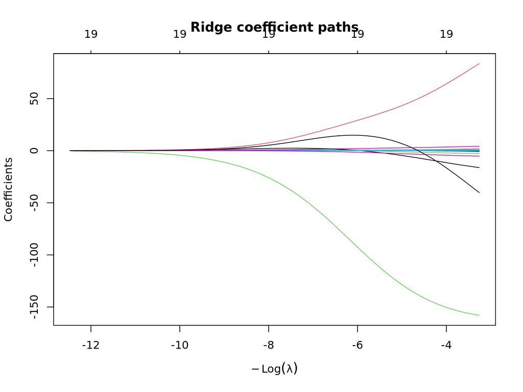

```r
plot(hitters_fit$ridge$glmnet.fit, xvar = "lambda", main = "Ridge coefficient paths")
```

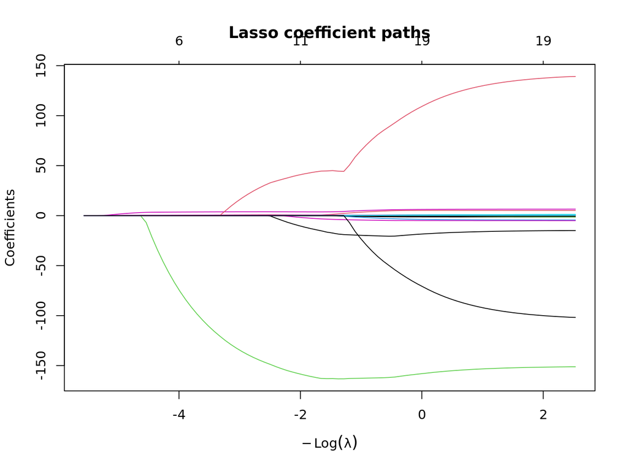

```r
plot(hitters_fit$lasso$glmnet.fit, xvar = "lambda", main = "Lasso coefficient paths")
```

# Cross-validation curves

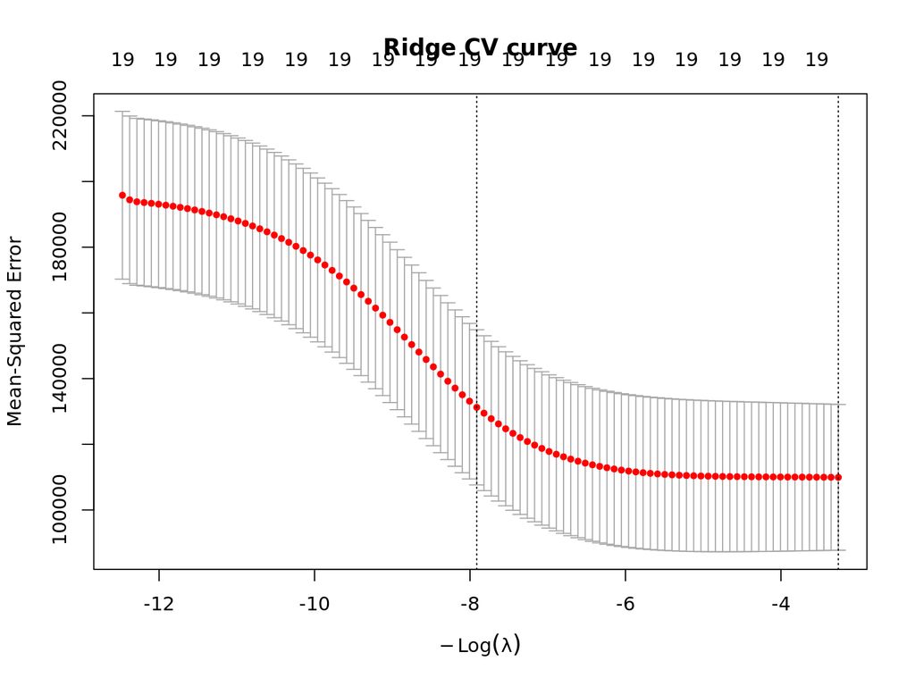

```r
plot(hitters_fit$ridge, main = "Ridge CV curve")
```

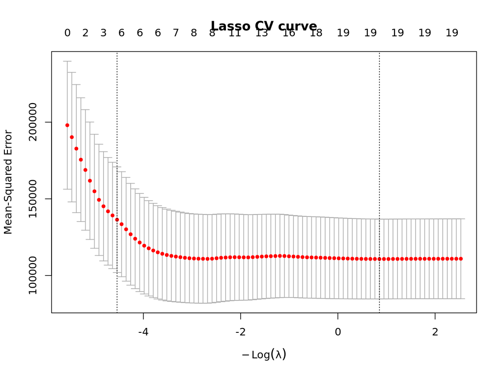

```r
plot(hitters_fit$lasso, main = "Lasso CV curve")
```

# Practice prompts

Try these modifications on your own:

1. Change the train/test split seed and see how stable your conclusions are.
2. Change elastic net alpha from 0.1 to 0.9 and record what changes.
3. Standardize your own synthetic data and compare results.
4. Create a dataset with strongly correlated predictors and see whether lasso picks one and drops the rest.
5. Increase noise and see whether ridge becomes more competitive.

# Rules of thumb you should discover

By the end of this practice, you should notice patterns like these:

- Ridge is often strong when many predictors all carry a little signal, especially when predictors are correlated.
- Lasso is often strong when only a smaller subset of variables truly matters.
- Elastic net is often helpful when predictors come in correlated groups and you want some shrinkage plus some selection.

# Short answer: R Markdown vs R Notebook

Both are usually `.Rmd` files.

- **R Markdown** is the file format: text + code chunks + output options.
- **R Notebook** is usually an R Markdown document with notebook-style behavior in RStudio, where chunks can run interactively and show previews inline.

In practice: - If you want something easy to knit into HTML/PDF, use **R Markdown**. - If you want an interactive lab experience while coding in RStudio, use an **R Notebook**. - The difference is mostly in the output style and workflow, not the core syntax.